# R Notebook

1. Use read.delim function to read Su_raw_matrix.txt into a variable called su (Notice that su has become a data frame now):

```r
# Su_raw_matrix.txt is in my working directory
su <- read.delim("Su_raw_matrix.txt")
```

2. Use mean and sd functions to find mean and standard deviation of Liver_2.CEL column:

```r
# "Liver_2.CEL"
mean_value <- mean(su$Liver_2.CEL)
sd_value <- sd(su$Liver_2.CEL)

# Print the results
cat("Mean of Liver_2.CEL:", mean_value, "\n")
```

```
## Mean of Liver_2.CEL: 241.8246
```

```r
cat("Standard Deviation of Liver_2.CEL:", sd_value, "\n")
```

```
## Standard Deviation of Liver_2.CEL: 1133.352
```

3. Use colMeans and colSums functions to get the average and total values of each column:

```r
# su is the data frame
average_values <- colMeans(su)
total_values <- colSums(su)

# Print the results
cat("Average values of each column:\n")
```

```
## Average values of each column:
```

```r
print(average_values)
```

```
##       Brain_1.CEL       Brain_2.CEL Fetal_brain_1.CEL Fetal_brain_2.CEL
##          204.9763          315.0924          198.3439          267.6551
## Fetal_liver_1.CEL Fetal_liver_2.CEL       Liver_1.CEL       Liver_2.CEL
##          209.8722          399.1482          160.8558          241.8246
```

```r
cat("\nTotal values of each column:\n")
```

```
##
## Total values of each column:
```

```r
print(total_values)
```

```
##       Brain_1.CEL       Brain_2.CEL Fetal_brain_1.CEL Fetal_brain_2.CEL
##           2588031           3978357           2504290           3379413
## Fetal_liver_1.CEL Fetal_liver_2.CEL       Liver_1.CEL       Liver_2.CEL
##           2649846           5039645           2030966           3053278
```

## QUESTION 2

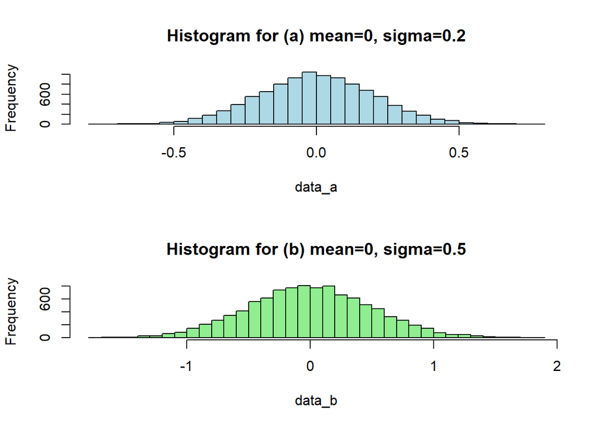

```r
# Set seed for reproducibility
set.seed(123)

# Generate 10000 random numbers for each case
data_a <- rnorm(10000, mean = 0, sd = 0.2)
data_b <- rnorm(10000, mean = 0, sd = 0.5)

# Plot histograms
par(mfrow = c(2, 1))  # Arrange plots in 2 rows, 1 column

hist(data_a, main = "Histogram for (a) mean=0, sigma=0.2", col = "lightblue", breaks = 30)
hist(data_b, main = "Histogram for (b) mean=0, sigma=0.5", col = "lightgreen", breaks = 30)
```

##Question 3

```r
# (a) Create the 'dat' dataframe
library(ggplot2)
dat <- data.frame(cond = factor(rep(c("A", "B"), each = 200)),
                  rating = c(rnorm(200), rnorm(200, mean = 0.8)))
```

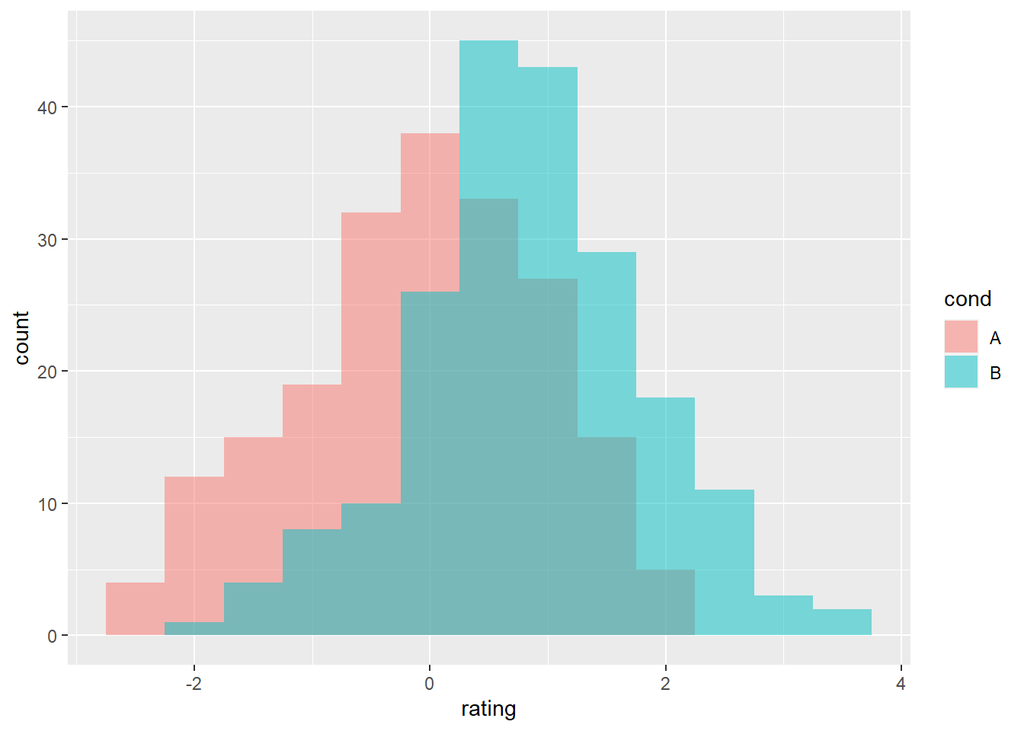

```r
# (b) Overlaid histograms
ggplot(dat, aes(x = rating, fill = cond)) +
  geom_histogram(binwidth = 0.5, alpha = 0.5, position = "identity")
```

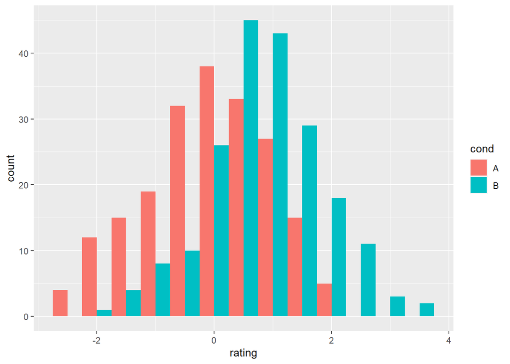

```r
# (c) Interleaved histograms
ggplot(dat, aes(x = rating, fill = cond)) +
  geom_histogram(binwidth = 0.5, position = "dodge")
```

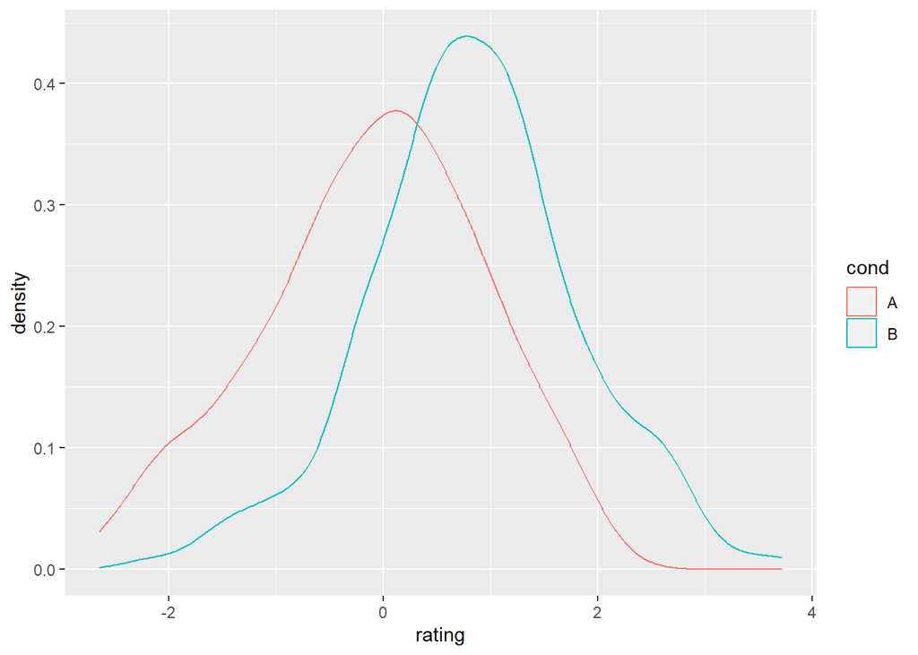

```r
# (d) Density plots
ggplot(dat, aes(x = rating, colour = cond)) +
  geom_density()
```

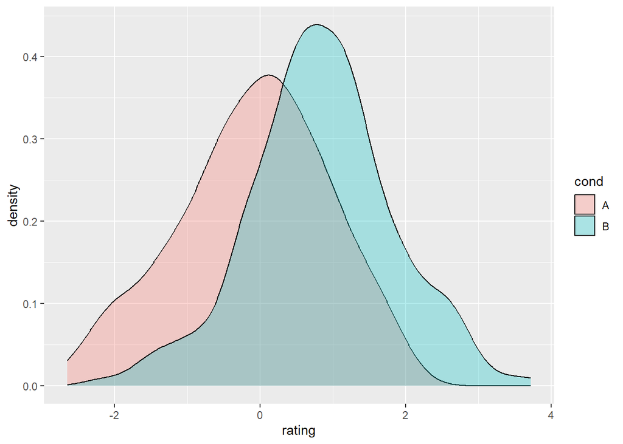

```r
# (e) Density plots with semitransparent fill
ggplot(dat, aes(x = rating, fill = cond)) +
  geom_density(alpha = 0.3)
```

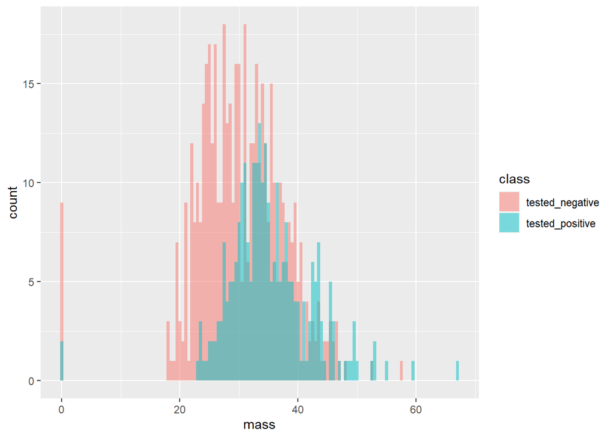

```r
# (f) Read "diabetes_train.csv" into a variable called diabetes
diabetes <- read.csv("diabetes_train.csv")

# Overlaid histograms for 'mass' attribute of diabetes
ggplot(diabetes, aes(x = mass, fill = class)) +
  geom_histogram(binwidth = 0.5, alpha = 0.5, position = "identity")
```

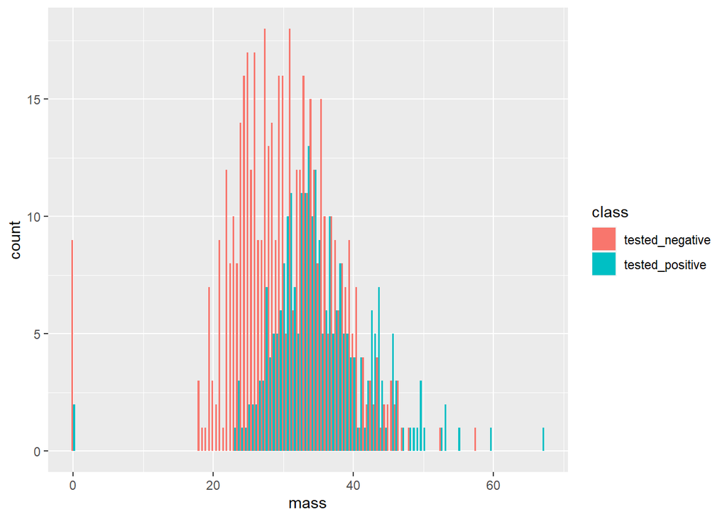

```r
# Interleaved histograms for 'mass' attribute of diabetes
ggplot(diabetes, aes(x = mass, fill = class)) +
  geom_histogram(binwidth = 0.5, position = "dodge")
```

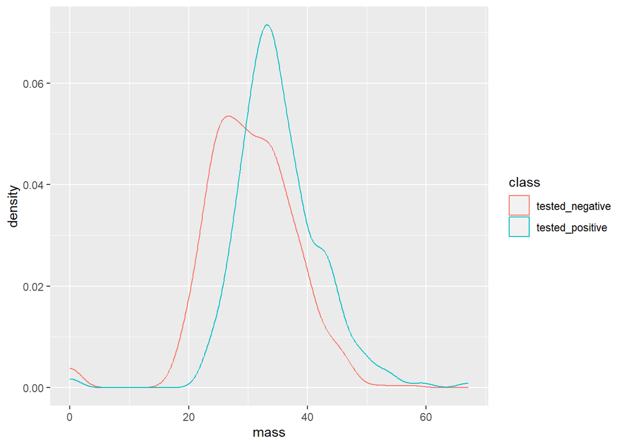

```r
# Density plots for 'mass' attribute of diabetes
ggplot(diabetes, aes(x = mass, colour = class)) +
  geom_density()
```

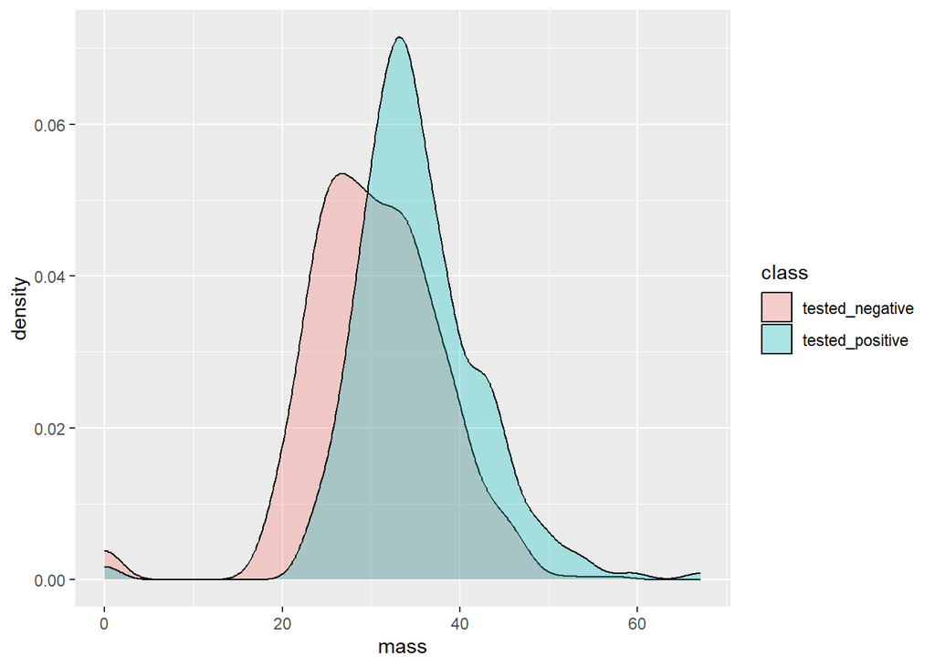

```r
# Density plots with semitransparent fill for 'mass' attribute of diabetes
ggplot(diabetes, aes(x = mass, fill = class)) +
  geom_density(alpha = 0.3)
```

#A Explanation: This operation is performed using the %>% (pipe) operator from the dplyr package. drop_na(): Removes rows with missing values (NA) from the dataset. summary(): Provides a summary of the dataset, including statistical measures for each column.

```r
# Load the necessary packages
library(tidyverse)
# Read the titanic.csv file from DATA folder to a variable named passengers
passengers <- read.csv("titanic.csv")

# (a) Remove rows with missing values and provide a summary of the dataset
summary_data <- passengers %>% drop_na() %>% summary()
print(summary_data)
```

```
##        X          PassengerId       Survived         Pclass
##  Min.   :  0.0   Min.   :  1.0   Min.   :0.0000   Length:714
##  1st Qu.:221.2   1st Qu.:222.2   1st Qu.:0.0000   Class :character
##  Median :444.0   Median :445.0   Median :0.0000   Mode  :character
##  Mean   :447.6   Mean   :448.6   Mean   :0.4062
##  3rd Qu.:676.8   3rd Qu.:677.8   3rd Qu.:1.0000
##  Max.   :890.0   Max.   :891.0   Max.   :1.0000
##      Name               Sex                 Age            SibSp
##  Length:714         Length:714         Min.   : 0.42   Min.   :0.0000
##  Class :character   Class :character   1st Qu.:20.12   1st Qu.:0.0000
##  Mode  :character   Mode  :character   Median :28.00   Median :0.0000
##                                        Mean   :29.70   Mean   :0.5126
##                                        3rd Qu.:38.00   3rd Qu.:1.0000
##                                        Max.   :80.00   Max.   :5.0000
##      Parch           Ticket               Fare           Cabin
##  Min.   :0.0000   Length:714         Min.   :  0.00   Length:714
##  1st Qu.:0.0000   Class :character   1st Qu.:  8.05   Class :character
##  Median :0.0000   Mode  :character   Median : 15.74   Mode  :character
##  Mean   :0.4314                      Mean   : 34.69
##  3rd Qu.:1.0000                      3rd Qu.: 33.38
##  Max.   :6.0000                      Max.   :512.33
##    Embarked
##  Length:714
##  Class :character
##  Mode  :character
##
##
##
```

##B Explanation: This operation filters the dataset to include only rows where the ‘Sex’ column is equal to “male”. filter(Sex == “male”): Retains only those rows where the ‘Sex’ column is “male”.

```r
# (b) Filter the data to include only male passengers
male_passengers <- passengers %>% filter(Sex == "male")
print(male_passengers)
```

```
##       X PassengerId Survived Pclass
## 1     0           1        0      3
## 2     4           5        0      3
## 3     5           6        0      3
## 4     6           7        0      1
## 5     7           8        0      3
## 6    12          13        0      3
## 7    13          14        0      3
## 8    16          17        0      3
## 9    17          18        1      2
## 10   20          21        0      2
## 11   21          22        1      2
## 12   23          24        1      1
## 13   26          27        0      3
## 14   27          28        0      1
```

[output cut: 1719 more lines]

#C Explanation: This operation arranges the dataset in descending order based on the ‘Fare’ column. arrange(desc(Fare)): Sorts the dataset in descending order of ‘Fare’.

```r
# (c) Arrange the data in descending order based on Fare
sorted_passengers <- passengers %>% arrange(desc(Fare))
print(sorted_passengers)
```

```
##       X PassengerId Survived Pclass
## 1   258         259        1      1
## 2   679         680        1      1
## 3   737         738        1      1
## 4    27          28        0      1
## 5    88          89        1      1
## 6   341         342        1      1
## 7   438         439        0      1
## 8   311         312        1      1
## 9   742         743        1      1
## 10  118         119        0      1
## 11  299         300        1      1
## 12  380         381        1      ?
## 13  557         558        0      1
## 14  700         701        1      1
```

[output cut: 3553 more lines]

#D Explanation: This operation adds a new column ‘FamSize’ to the dataset, representing the sum of ‘Parch’ (number of parents/children aboard) and ‘SibSp’ (number of siblings/spouses aboard). mutate(FamSize = Parch + SibSp): Creates a new column ‘FamSize’ with the sum of ‘Parch’ and ‘SibSp’. This can help in analyzing the family size of each passenger.

```r
# (d) Create a new column 'FamSize' that is the sum of 'Parch' and 'SibSp'
passengers_with_famsize <- passengers %>% mutate(FamSize = Parch + SibSp)
print(passengers_with_famsize)
```

```
##       X PassengerId Survived Pclass
## 1     0           1        0      3
## 2     1           2        1      1
## 3     2           3        1      3
## 4     3           4        1      1
## 5     4           5        0      3
## 6     5           6        0      3
## 7     6           7        0      1
## 8     7           8        0      3
## 9     8           9        1      3
## 10    9          10        1      2
## 11   10          11        1      3
## 12   11          12        1      1
## 13   12          13        0      3
## 14   13          14        0      3
```

[output cut: 3553 more lines]

#E Explanation: This operation groups the dataset by the ‘Sex’ column and calculates summary statistics within each group. group_by(Sex): Groups the data by the ‘Sex’ column, allowing for separate calculations for male and female passengers. summarise(meanFare = mean(Fare), numSurv = sum(Survived)): Calculates the mean ‘Fare’ and total number of ‘Survived’ passengers for each gender group. This can provide insights into average fare expenses and survival rates based on gender.

```r
# (e)
grouped_passengers <- passengers %>% group_by(Sex) %>% summarise(meanFare = mean(Fare), numSurv = sum(Survived))
print(grouped_passengers)
```

```
## # A tibble: 2 × 3
##   Sex    meanFare numSurv
##   <chr>     <dbl>   <int>
## 1 female     44.5     233
## 2 male       25.5     109
```

#Question 6

```r
percentiles <- quantile(diabetes$skin, c(0.1, 0.3, 0.5, 0.6))

# Print the results
cat("10th percentile:", percentiles[1], "\n")
```

```
## 10th percentile: 0
```

```r
cat("30th percentile:", percentiles[2], "\n")
```

```
## 30th percentile: 10
```

```r
cat("50th percentile (median):", percentiles[3], "\n")
```

```
## 50th percentile (median): 23
```

```r
cat("60th percentile:", percentiles[4], "\n")
```

```
## 60th percentile: 27
```